# Data Camp Python Notes

davegoblue

September 3, 2017

## Background and Overview

DataCamp offer interactive courses related to Python Programming. Since R Markdown documents can run simple Python code chunks (though the data is not accessible to future chunks, a large difference from R Markdown for R), this document attempts to summarize notes from the modules when possible.

Topic areas summarized include:

- Python Programming (Introduction, Intermediate, Toolbox I/II, Network Analysis I/II)
- Python Import and Clean Data (Import I/II, Clean)
- Python Data Manipulation (pandas Foundations, Manipulating DF with pandas, Merging DF with pandas, Databases in pandas, Data Types)
- Python Visualization (Introduction to Python Data Visualization, Interactive Visualization with Bokeh)
- Python Statistics (Statistical Thinking in Python Parts I/II)
- Python Machine Learning ()

The complete version as of July 31, 2017 has been archived as DataCamp_PythonNotes_v001. Archive files for DataCamp_Python_ImportClean_v002 and DataCamp_Python_Programming_v002 have also been created to contain summaries of those areas. Further, DataCamp_PythonNotes_v002 was created for capturing summaries of additional topics.

The version of DataCamp_PythonNotes_v002 as of September 1, 2017 has been archived. Archive files for DataCamp_Python_DataManipulation_v003 and DataCamp_Python_Visualization_v003 have also been created to contain summaries of these areas. Further, DataCamp_PythonNotes_v003 was created for capturing summaries of additional topics.

This document includes:

- Python Statistics (Statistical Thinking in Python Parts I/II)
- Python Machine Learning ()

## Python Statistics

### *Statistical Thinking in Python (Part I)*

Chapter 1 - Graphical exploratory data analysis

Introduction to exploratory data analysis - organizing, plotting, and summarizing data (ala Tukey):

- Example of swing voter dataset (by county) of 2008 election
- Conversion of tabular data (e.g., pandas DataFrame) to visual data

Plotting a histogram - using matplotlib.pyplot.hist (plt.hist):

- plt.hist() will create the basic hsitogram
  - Can accessorize with plt.xlabel(“myXLabel”) and plt.ylabel(“myYLabel”)
  - Can send the bins with a bins= call ; can be a list of actual bin cut-points, or a single integer requesting that number of evenly spaced bins
- Common practice in Python is to assign _ = plt.hist() to avoid the screen being printed with the 3 histogram data outputs
- Can customize with the Seaborn styling (package developed by Waskom)
  - import seaborn as sns
  - sns.set() # makes Seaborn style the default for graphing

Plotting all data (bee swarm plots):

- Binning bias can lead to the same data being interpreted differently based on different binning in different histograms
- The swarm plot has the individual points plotted, segmented by categorical variables if appropriate, in a fashion like “jitter” where each point is visible
- Seaborn can manage swarm plots easilt, provided that data are in a well-organized DataFrame (rows as observations, columns as features)
  - sns.swarmplot(x=“xVar”, y=“yVar”, data=myFrame)
  - plt.show()

Plotting all data (ECDF = empirical CDF) - especially when swarm plot would be too messy (too much data):

- The ECDF has the y-axis as the cumulative percentile (total amount of data that is smaller than the designated x value)
- Suppose that a DataFrame df_swing already exists, with a column called “dem_share”
  - x = np.sort(df_swing[“dem_share”])
  - y = np.arange(1, len(x) + 1) / len(x)
  - _ = plt.plot(x, y, marker=“.”, linestyle=“none”) # will make dot markers and with no lines
  - plt.margins(0.02) # keeps the data from running over the side of the plot
- Generally, ECDF is a good starting point for analysis - keeps all the data, provides a simple summary

Onward toward the whole story - starting with graphical EDA as per Tukey:

- Chapter 2 - Build on graphical EDA with quantitative EDA
- Chapter 3/4 - Probabilistic distributions to draw meaningful conclusions (Hacker statistics)
- Part II - continuing to build towards “the full story”

Example code includes:

```python
myPath = "./PythonInputFiles/"



# Import plotting modules
import matplotlib.pyplot as plt
import seaborn as sns


import pandas as pd

rawIris = pd.read_csv(myPath + "iris.csv")
versicolor_petal_length = rawIris.loc[rawIris["Species"] == "versicolor", "Petal.Length"]



# Set default Seaborn style
sns.set()

# Plot histogram of versicolor petal lengths
plt.hist(versicolor_petal_length)

# Show histogram
# plt.show()
plt.savefig("_dummyPy149.png", bbox_inches="tight")
plt.clf()


# Plot histogram of versicolor petal lengths
_ = plt.hist(versicolor_petal_length)

# Label axes
_ = plt.xlabel('petal length (cm)')
_ = plt.ylabel('count')

# Show histogram
# plt.show()
plt.savefig("_dummyPy150.png", bbox_inches="tight")
plt.clf()


# Import numpy
import numpy as np

# Compute number of data points: n_data
n_data = len(versicolor_petal_length)

# Number of bins is the square root of number of data points: n_bins
n_bins = n_data ** 0.5

# Convert number of bins to integer: n_bins
n_bins = int(n_bins)

# Plot the histogram
_ = plt.hist(versicolor_petal_length, bins=n_bins)

# Label axes
_ = plt.xlabel('petal length (cm)')
_ = plt.ylabel('count')

# Show histogram
# plt.show()
plt.savefig("_dummyPy151.png", bbox_inches="tight")
plt.clf()



df = rawIris[["Species", "Petal.Length"]]
df.columns = ["species", "petal length (cm)"]

# Create bee swarm plot with Seaborn's default settings
_ = sns.swarmplot(x="species", y="petal length (cm)", data=df)

# Label the axes
_ = plt.xlabel('Species')
_ = plt.ylabel("Petal Length (cm)")

# Show the plot
# plt.show()
plt.savefig("_dummyPy152.png", bbox_inches="tight")
plt.clf()


def ecdf(data):
    """Compute ECDF for a one-dimensional array of measurements."""

    # Number of data points: n
    n = len(data)

    # x-data for the ECDF: x
    x = np.sort(data)

    # y-data for the ECDF: y
    y = np.arange(1, n+1) / n

    return x, y

# Compute ECDF for versicolor data: x_vers, y_vers
x_vers, y_vers = ecdf(versicolor_petal_length)

# Generate plot
_ = plt.plot(x_vers, y_vers, marker=".", linestyle="none")

# Make the margins nice
plt.margins(0.02)

# Label the axes
_ = plt.xlabel("Versicolor Petal Length (cm)")
_ = plt.ylabel("ECDF")

# Display the plot
# plt.show()
plt.savefig("_dummyPy153.png", bbox_inches="tight")
plt.clf()


setosa_petal_length = rawIris.loc[rawIris["Species"] == "setosa", "Petal.Length"]
virginica_petal_length = rawIris.loc[rawIris["Species"] == "virginica", "Petal.Length"]

# Compute ECDFs
x_set, y_set = ecdf(setosa_petal_length)
x_vers, y_vers = ecdf(versicolor_petal_length)
x_virg, y_virg = ecdf(virginica_petal_length)

# Plot all ECDFs on the same plot
_ = plt.plot(x_set, y_set, marker=".", linestyle="none")
_ = plt.plot(x_vers, y_vers, marker=".", linestyle="none")
_ = plt.plot(x_virg, y_virg, marker=".", linestyle="none")

# Make nice margins
plt.margins(0.02)

# Annotate the plot
plt.legend(('setosa', 'versicolor', 'virginica'), loc='lower right')
_ = plt.xlabel('petal length (cm)')
_ = plt.ylabel('ECDF')

# Display the plot
# plt.show()
plt.savefig("_dummyPy154.png", bbox_inches="tight")
plt.clf()
```

**Example #1: Default Histogram**:

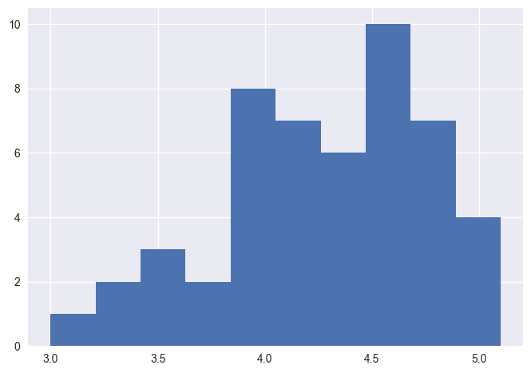

**Example #2: Labeled Histogram**:

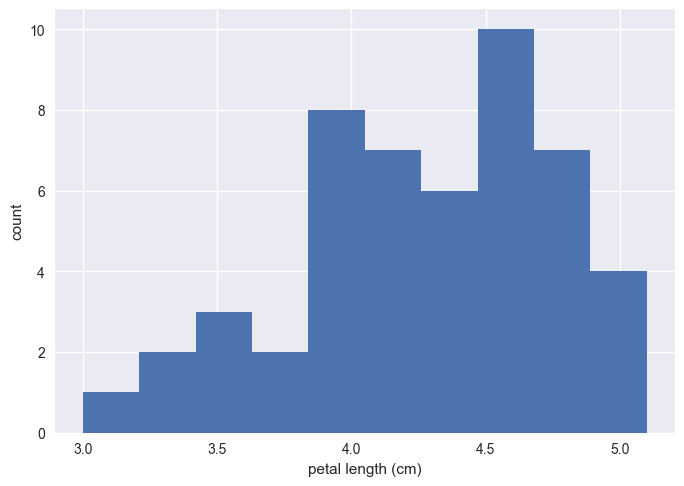

**Example #3: Custom-Binned Histogram**:

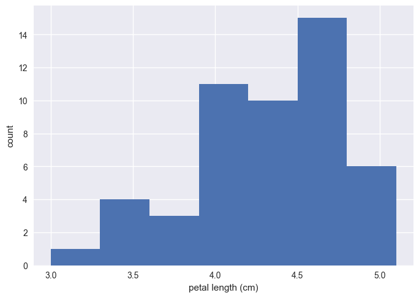

**Example #4: Swarm Plot**:

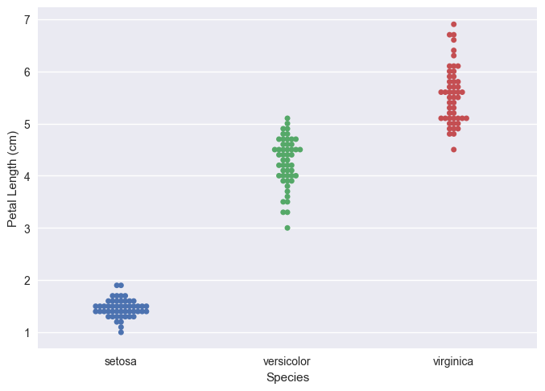

**Example #5: ECDF (Single Species)**:

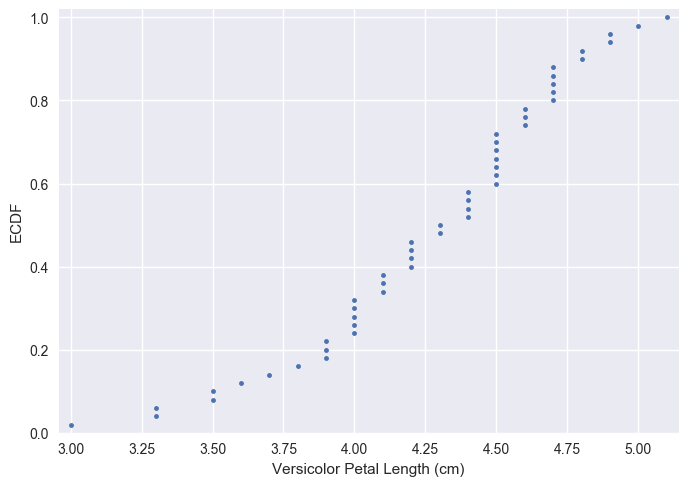

**Example #6: ECDF (Multiple Species)**:

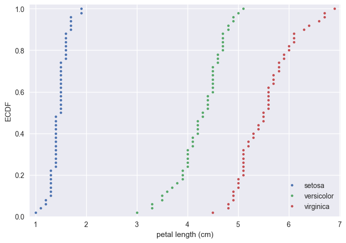

Chapter 2 - Quantitative exploratory data analysis

Introduction to summary statistics: sample mean and median:

- Means or medians can be added as horizontal lines on the bee swarm plot
  - np.mean(myData)
  - np.median(myData)

Percentiles, outliers, and box plots:

- Can grab multiple percentiles using np.percentile(myData, [myPercentileList]) # note that percentiles should be passed, so 25 means 0.25 or 25th percentile
- Box plots can help to display much of the percentile data simultaneously - center is median, box edges are 0.25/0.75, end of whsikers is 1.5 * IQR (unless data is narrower), with outliers graphed separately
- _ = sns.boxplot(x=“xVar”, y=“yVar”, data=myData)

Variance and standard deviation:

Covariance and Pearson correlation coefficient:

- Initial graphical EDA could come from graphing the data as points, using plt.plot(xVar, yVar, marker=“.”, linestyle=“none”)
- Covariance - how to variables run together (mean of product of differences from x-mean, y-mean)
- Correlation - adds the advantages of dimensionless and scaled from -1 to 1
  - Pearson correlation coefficient (rho) - Covariances / [Std(x) * Std(y) ]

Example code includes:

```python
myPath = "./PythonInputFiles/"



import pandas as pd
import numpy as np
import seaborn as sns
import matplotlib.pyplot as plt


rawIris = pd.read_csv(myPath + "iris.csv")
versicolor_petal_length = rawIris.loc[rawIris["Species"] == "versicolor", "Petal.Length"]
versicolor_petal_width = rawIris.loc[rawIris["Species"] == "versicolor", "Petal.Width"]


# Compute the mean: mean_length_vers
mean_length_vers = np.mean(versicolor_petal_length)

# Print the result with some nice formatting
print('I. versicolor:', mean_length_vers, 'cm')


# Specify array of percentiles: percentiles
percentiles = np.array([2.5, 25, 50, 75, 97.5])

# Compute percentiles: ptiles_vers
ptiles_vers = np.percentile(versicolor_petal_length, percentiles)

# Print the result
print(ptiles_vers)


def ecdf(data):
    """Compute ECDF for a one-dimensional array of measurements."""

    # Number of data points: n
    n = len(data)

    # x-data for the ECDF: x
    x = np.sort(data)

    # y-data for the ECDF: y
    y = np.arange(1, n+1) / n

    return x, y

# Compute ECDF for versicolor data: x_vers, y_vers
x_vers, y_vers = ecdf(versicolor_petal_length)


# Plot the ECDF
_ = plt.plot(x_vers, y_vers, '.')
plt.margins(0.02)
_ = plt.xlabel('petal length (cm)')
_ = plt.ylabel('ECDF')

# Overlay percentiles as red diamonds.
_ = plt.plot(ptiles_vers, percentiles/100, marker='D', color='red',
         linestyle="none")

# Show the plot
# plt.show()
plt.savefig("_dummyPy155.png", bbox_inches="tight")
plt.clf()


df = rawIris[["Species", "Petal.Length"]]
df.columns = ["species", "petal length (cm)"]


# Create box plot with Seaborn's default settings
_ = sns.boxplot(x="species", y="petal length (cm)", data=df)

# Label the axes
_ = plt.xlabel("Species")
_ = plt.ylabel("Petal Length (cm)")

# Show the plot
# plt.show()
plt.savefig("_dummyPy156.png", bbox_inches="tight")
plt.clf()


# Array of differences to mean: differences
differences = versicolor_petal_length - np.mean(versicolor_petal_length)

# Square the differences: diff_sq
diff_sq = differences ** 2

# Compute the mean square difference: variance_explicit
variance_explicit = np.mean(diff_sq)

# Compute the variance using NumPy: variance_np
variance_np = np.var(versicolor_petal_length)

# Print the results
print(variance_explicit, variance_np)


# Compute the variance: variance
variance = np.var(versicolor_petal_length)

# Print the square root of the variance
print(variance ** 0.5)

# Print the standard deviation
print(np.std(versicolor_petal_length))


# Make a scatter plot
_ = plt.plot(versicolor_petal_length, versicolor_petal_width, marker=".", linestyle="none")

# Set margins
plt.margins(0.02)

# Label the axes
_ = plt.xlabel("Petal Length (cm)")
_ = plt.ylabel("Petal Width (cm)")

# Show the result
# plt.show()
plt.savefig("_dummyPy157.png", bbox_inches="tight")
plt.clf()


# Compute the covariance matrix: covariance_matrix
covariance_matrix = np.cov(versicolor_petal_length, versicolor_petal_width)

# Print covariance matrix
print(covariance_matrix)

# Extract covariance of length and width of petals: petal_cov
petal_cov = covariance_matrix[0, 1]

# Print the length/width covariance
print(petal_cov)


def pearson_r(x, y):
    """Compute Pearson correlation coefficient between two arrays."""
    # Compute correlation matrix: corr_mat
    corr_mat = np.corrcoef(x, y)

    # Return entry [0,1]
    return corr_mat[0,1]

# Compute Pearson correlation coefficient for I. versicolor: r
r = pearson_r(versicolor_petal_length, versicolor_petal_width)

# Print the result
print(r)
```

```
## I. versicolor: 4.26 cm
## [ 3.3     4.      4.35    4.6     4.9775]
## 0.21640000000000012 0.21640000000000012
## 0.4651881339845204
## 0.4651881339845204
## [[ 0.22081633  0.07310204]
##  [ 0.07310204  0.03910612]]
## 0.0731020408163
## 0.786668088523
```

**Example #1: ECDF with Key Percentiles**:

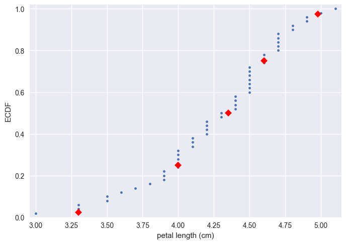

**Example #2: Box Plot**:

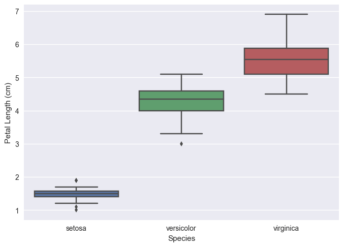

**Example #3: Scatter Plot**:

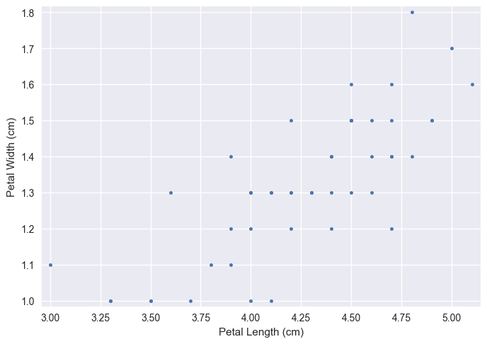

Chapter 3 - Thinking Probabilistically (Discrete Variables)

Probabilistic logic and statistical inference - drawing conclusions about the population based on my sample:

- Multiple re-samples will generate multiple means

Random number generators and hacker statistics - tool for thinking probabilistically:

- Use simulated repeated measurements to compute probabilities
- Initial simulations were run on games of chance (particularly coin flips) by Pascal et al
- The NumPy module has many useful random number generators
  - np.random.random(size=n) # draws “n” random numbers between 0 and 1
  - np.random.seed() # allows for providing a seed for re-producibility
- Hacker statistics - define simulation, run many times, summarize key statistic of interest

Probability distributions - Binomial:

- Probability Mass Function (PMF) - set of probabilities of discrete outcomes
  - Rolling a dice is an example - can only get discrete values (integers 1-6)
- Binomial Distribution - the number of successes, r, in n Bernoullie trials with probability p of success will be binomially distributed
  - np.random.binomial(nTrials, pSuccess, size=n) # will simulate the sum of successes in the nTrials each with pSuccess ; will create a 1D array of length n by repeating the simulation n times

Poisson processes and distributions - specified solely by a rate, independent of any previous events:

- Natural births in a hospital, timing of hits to a website, etc.
- Poisson distribution - the number r of arrivals of a Poisson process in a given time period with an average rate lambda of arrivals is Poisson distributed
- The Poisson distribution is a limiting case of the Binomial distribution when there is a low succes probability but a large amount of time – i.e., rare events
  - np.random.poisson(param, size=) # where param is the expected number of events and size is the number of simulations desired

Example code includes:

```python
myPath = "./PythonInputFiles/"



import pandas as pd
import numpy as np
import seaborn as sns
import matplotlib.pyplot as plt



# Seed the random number generator
np.random.seed(42)

# Initialize random numbers: random_numbers
random_numbers = np.empty(100000)

# Generate random numbers by looping over range(100000)
for i in range(100000):
    random_numbers[i] = np.random.random()

# Plot a histogram
_ = plt.hist(random_numbers)

# Show the plot
# plt.show()
plt.savefig("_dummyPy158.png", bbox_inches="tight")
plt.clf()


def perform_bernoulli_trials(n, p):
    """Perform n Bernoulli trials with success probability p
    and return number of successes."""
    # Initialize number of successes: n_success
    n_success = 0

    # Perform trials
    for i in range(n):
        # Choose random number between zero and one: random_number
        random_number = np.random.random()

        # If less than p, it's a success so add one to n_success
        if random_number < p:
            n_success +=1

    return n_success


# Seed random number generator
np.random.seed(42)

# Initialize the number of defaults: n_defaults
n_defaults = np.empty(1000)

# Compute the number of defaults
for i in range(1000):
    n_defaults[i] = perform_bernoulli_trials(100, 0.05)

# Plot the histogram with default number of bins; label your axes
_ = plt.hist(n_defaults, normed=True)
_ = plt.xlabel('number of defaults out of 100 loans')
_ = plt.ylabel('probability')

# Show the plot
# plt.show()
plt.savefig("_dummyPy159.png", bbox_inches="tight")
plt.clf()


def ecdf(data):
    """Compute ECDF for a one-dimensional array of measurements."""

    # Number of data points: n
    n = len(data)

    # x-data for the ECDF: x
    x = np.sort(data)

    # y-data for the ECDF: y
    y = np.arange(1, n+1) / n

    return x, y


# Compute ECDF: x, y
x, y = ecdf(n_defaults)  # same function as written in previous chapters

# Plot the ECDF with labeled axes
_ = plt.plot(x, y, marker=".", linestyle="none")
_ = plt.xlabel("Number of Defaults in Simulation")
_ = plt.ylabel("ECDF")

# Show the plot
# plt.show()
plt.savefig("_dummyPy160.png", bbox_inches="tight")
plt.clf()


# Compute the number of 100-loan simulations with 10 or more defaults: n_lose_money
n_lose_money = np.sum(n_defaults >= 10)

# Compute and print probability of losing money
print('Probability of losing money =', n_lose_money / len(n_defaults))


# Take 10,000 samples out of the binomial distribution: n_defaults
n_defaults = np.random.binomial(100, 0.05, size=10000)

# Compute CDF: x, y
x, y = ecdf(n_defaults)

# Plot the CDF with axis labels
_ = plt.plot(x, y, marker=".", linestyle="none")
_ = plt.xlabel("Defaults in 100 loans")
_ = plt.ylabel("CDF")

# Show the plot
# plt.show()
plt.savefig("_dummyPy161.png", bbox_inches="tight")
plt.clf()


# Compute bin edges: bins
bins = np.arange(min(n_defaults), max(n_defaults) + 2) - 0.5

# Generate histogram
_ = plt.hist(n_defaults, bins=bins, normed=True)

# Set margins
plt.margins(0.02)

# Label axes
_ = plt.xlabel("Number of Defaults in 100 Loans")
_ = plt.ylabel("Probability")

# Show the plot
# plt.show()
plt.savefig("_dummyPy162.png", bbox_inches="tight")
plt.clf()


# Draw 10,000 samples out of Poisson distribution: samples_poisson
samples_poisson = np.random.poisson(10, size=10000)

# Print the mean and standard deviation
print('Poisson:     ', np.mean(samples_poisson),
                       np.std(samples_poisson))

# Specify values of n and p to consider for Binomial: n, p
n = [20, 100, 1000]
p = [0.5, 0.1, 0.01]

# Draw 10,000 samples for each n,p pair: samples_binomial
for i in range(3):
    samples_binomial = np.random.binomial(n[i], p[i], size=10000)

    # Print results
    print('n =', n[i], 'Binom:', np.mean(samples_binomial),
                                 np.std(samples_binomial))


# Draw 10,000 samples out of Poisson distribution: n_nohitters
n_nohitters = np.random.poisson(251/115, size=10000)

# Compute number of samples that are seven or greater: n_large
n_large = np.sum(n_nohitters >= 7)

# Compute probability of getting seven or more: p_large
p_large = n_large / 10000

# Print the result
print('Probability of seven or more no-hitters:', p_large)
```

```
## Probability of losing money = 0.022
## Poisson:      10.0145 3.17135456075
## n = 20 Binom: 10.0592 2.23523944131
## n = 100 Binom: 10.0441 2.994253695
## n = 1000 Binom: 10.0129 3.13963908595
## Probability of seven or more no-hitters: 0.0072
```

**Example #1: Histogram of Random Numbers**:

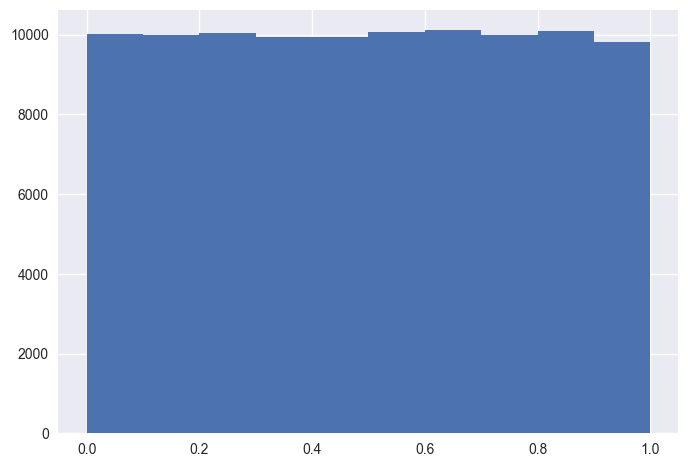

**Example #2: Histogram of 1000 Bernoulli Trials (each with p=0.05, n=100)**:

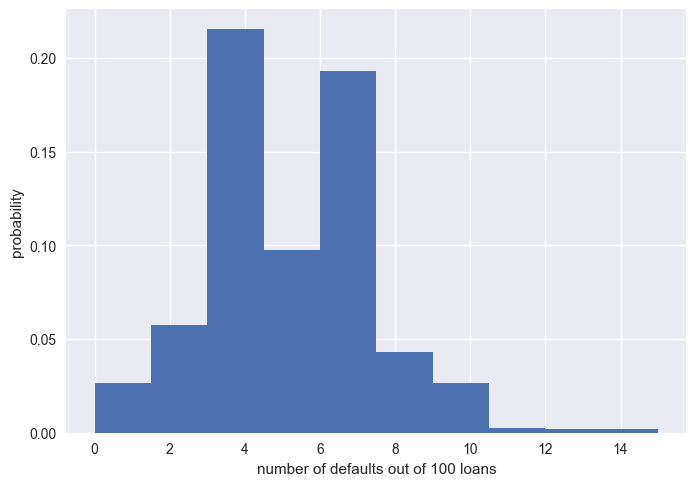

**Example #3: ECDF of 1000 Bernoulli Trials**:

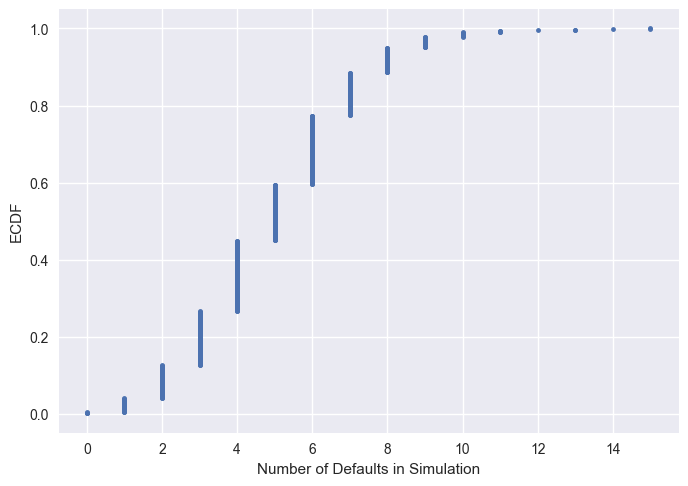

**Example #4: Histogram/ECDF of Binomial Trials (n=100, p=0.05, size=10000)**:

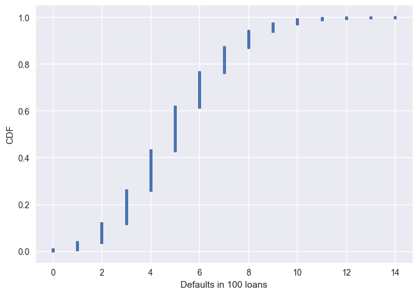

**Example #5: Normed Histogram with Customized Binning for Binomial Trials (n=100, p=0.05, size=10000)**:

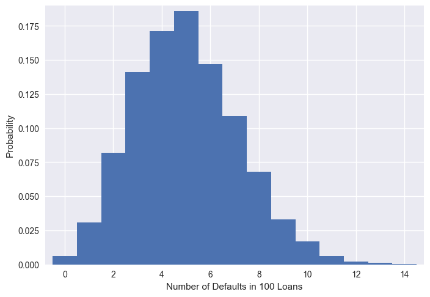

Chapter 4 - Thinking probabilistically - continuous variables

Probability density functions (PDF) - continuous analog to the PMF:

- Mathematical description of the relative likelihood of observing a value of a continuous variable
- Areas under the PDF describe the associated probabilities
- The CDF can be calculated from the PDF, and can be easier to interpret

Introduction to the Normal Distribution - continuous variable with a single peak:

- Mean - center of the peak
- Standard Deviation - degree of spread of the data around the peak
- To avoid binning bias, better to compare theoretical/actual CDF rather than histogram and theoretical curve overlaid
- To simulate normal data, call np.random.normal(mean, std, size=)

Normal distribution - properties and warnings:

- Commonly called the Gaussian dsitribution after its inventor (was previously featured on the German Deutschemark prior to adoption of the Euro)
- Important caveats include
  1. Sometimes, things that you think “should” be normally distributed in fact are not
  2. Normal distributions have very light tails (outliers are extremely unlikely), which often does not match to the real-world

Exponential distribution - related to the Poisson distribution:

- The expected number of occurences being Poisson distributed means that the expected time between events will be exponentially distributed
- The waiting time between arrivals of a Poisson distribution is exponentially distributed - defined by a single parameter, “mean waiting time”
  - np.random.exponential(mean, size=) # will simulate “size” times from an exponential with mean “mean”
- Simulating a story can be very powerful - existence of computers makes the “pen and paper” modelling less necessary in many cases

Final thoughts - course recap:

- Construct instructive plots
- Compute informative summary statistics
- Use hacker statistics
- Think probabilistically

Example code includes:

```python
myPath = "./PythonInputFiles/"



import pandas as pd
import numpy as np
import seaborn as sns
import matplotlib.pyplot as plt



# Draw 100000 samples from Normal distribution with stds of interest: samples_std1, samples_std3, samples_std10
samples_std1 = np.random.normal(20, 1, size=100000)
samples_std3 = np.random.normal(20, 3, size=100000)
samples_std10 = np.random.normal(20, 10, size=100000)

# Make histograms
_ = plt.hist(samples_std1, normed=True, histtype="step", bins=100)
_ = plt.hist(samples_std3, normed=True, histtype="step", bins=100)
_ = plt.hist(samples_std10, normed=True, histtype="step", bins=100)

# Make a legend, set limits and show plot
_ = plt.legend(('std = 1', 'std = 3', 'std = 10'))
plt.ylim(-0.01, 0.42)
# plt.show()
plt.savefig("_dummyPy163.png", bbox_inches="tight")
plt.clf()


def ecdf(data):
    """Compute ECDF for a one-dimensional array of measurements."""

    # Number of data points: n
    n = len(data)

    # x-data for the ECDF: x
    x = np.sort(data)

    # y-data for the ECDF: y
    y = np.arange(1, n+1) / n

    return x, y


# Generate CDFs
x_std1, y_std1 = ecdf(samples_std1)  # function written earlier in previous chapter
x_std3, y_std3 = ecdf(samples_std3)
x_std10, y_std10 = ecdf(samples_std10)

# Plot CDFs
_ = plt.plot(x_std1, y_std1, marker=".", linestyle="none")
_ = plt.plot(x_std3, y_std3, marker=".", linestyle="none")
_ = plt.plot(x_std10, y_std10, marker=".", linestyle="none")

# Make 2% margin
plt.margins(0.02)

# Make a legend and show the plot
_ = plt.legend(('std = 1', 'std = 3', 'std = 10'), loc='lower right')
# plt.show()
plt.savefig("_dummyPy164.png", bbox_inches="tight")
plt.clf()


rawBelmont = pd.read_csv(myPath + "belmont_stakes_1926_2016.csv")

from datetime import datetime

listBelmont = [x.split(".") for x in rawBelmont["Time"]]
timeBelmont = [int(x[0].split(":")[0]) * 60 + int(x[0].split(":")[1]) + int(x[1])/100 for x in listBelmont]
belmont_no_outliers = timeBelmont


# Compute mean and standard deviation: mu, sigma
mu = np.mean(belmont_no_outliers)
sigma = np.std(belmont_no_outliers)

# Sample out of a normal distribution with this mu and sigma: samples
samples = np.random.normal(mu, sigma, size=10000)

# Get the CDF of the samples and of the data
x_theor, y_theor = ecdf(samples)
x, y = ecdf(belmont_no_outliers)

# Plot the CDFs and show the plot
_ = plt.plot(x_theor, y_theor)
_ = plt.plot(x, y, marker='.', linestyle='none')
plt.margins(0.02)
_ = plt.xlabel('Belmont winning time (sec.)')
_ = plt.ylabel('CDF')
# plt.show()
plt.savefig("_dummyPy165.png", bbox_inches="tight")
plt.clf()


# Take a million samples out of the Normal distribution: samples
samples = np.random.normal(mu, sigma, size=1000000)

# Compute the fraction that are faster than 144 seconds: prob
prob = np.mean(samples <= 144)

# Print the result
print('Probability of besting Secretariat:', prob)


def successive_poisson(tau1, tau2, size=1):
    # Draw samples out of first exponential distribution: t1
    t1 = np.random.exponential(tau1, size)

    # Draw samples out of second exponential distribution: t2
    t2 = np.random.exponential(tau2, size)

    return t1 + t2


# Draw samples of waiting times: waiting_times
waiting_times = successive_poisson(764, 715, size=100000)

# Make the histogram
_ = plt.hist(waiting_times, bins=100, normed=True, histtype="step")

# Label axes
_ = plt.xlabel("Total Waiting Time (Days) for Cycle and No-Hitter")
_ = plt.ylabel("PDF")

# Show the plot
# plt.show()
plt.savefig("_dummyPy166.png", bbox_inches="tight")
plt.clf()
```

```
## Probability of besting Secretariat: 0.00154
```

**Example #1: Histogram of Normal Distribution with Different STD**:

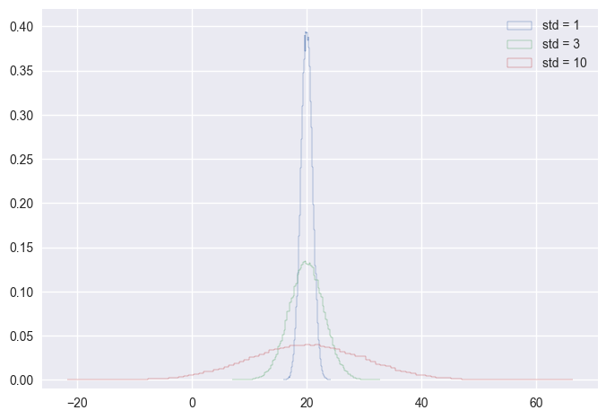

**Example #2: ECDF of Normal Distribution with Different STD**:

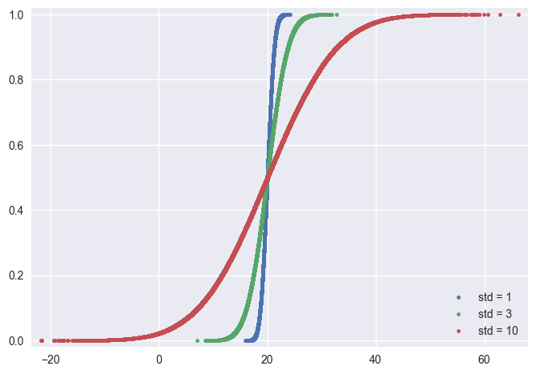

**Example #3: ECDF of Belmont Stakes Winning Times**:

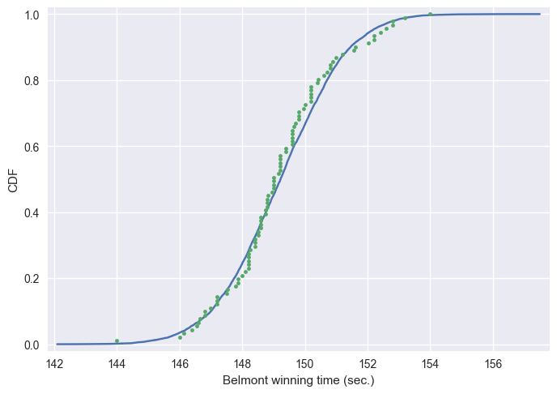

**Example #4: Sum of Poisson Outcomes**:

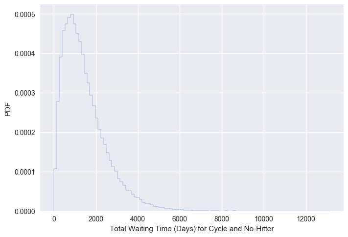

Chapter 1 - Parameter estimation by optimization

Optimal parameters - parameters that bring the model in closest agreement with the data:

- Parameters derived from the sample are relevant mainly to that sample; other samples might have other optimal parameters
- Two key packages for statistics in Python - scipy.stats and statsmodels
- For this course, though, the focus will be on hacker statistics - simulated data using numpy

Linear regression by least squares - fitting the best slope and intercept to the line:

- Residuals are the vertical distance between the data point and the regression line
- The “least squares” algorithm defines the best fit to be the line that minimizes the sum-squared residuals
- Regressions can be run in Python using np.polyfit() # least squares with polynomials
  - slope, intercept = np.polyfit(xData, yData, nDegree) # nDegree is the desired degree of the polynomial, which is to say 1 for linear regression

Importance of EDA (Anscombe’s quartet) - 4 fictitious datasets with the same x-bar, y-bar, correlation, and RSS:

- Graphical EDA is vital before diving in to the regression (or other) analysis

Example code includes:

```python
myPath = "./PythonInputFiles/"



import pandas as pd
import numpy as np
import seaborn as sns
import matplotlib.pyplot as plt



rawNoHitter = pd.read_csv(myPath + "mlb_nohitters.csv", parse_dates=["date"])
nohitter_times = rawNoHitter["game_number"].diff()[1:]

# Seed random number generator
np.random.seed(42)

# Compute mean no-hitter time: tau
tau = np.mean(nohitter_times)

# Draw out of an exponential distribution with parameter tau: inter_nohitter_time
inter_nohitter_time = np.random.exponential(tau, 100000)

# Plot the PDF and label axes
_ = plt.hist(inter_nohitter_time,
             bins=50, normed=True, histtype="step")
_ = plt.xlabel('Games between no-hitters')
_ = plt.ylabel('PDF')

# Show the plot
# plt.show()
plt.savefig("_dummyPy167.png", bbox_inches="tight")
plt.clf()



def ecdf(data):
    """Compute ECDF for a one-dimensional array of measurements."""

    # Number of data points: n
    n = len(data)

    # x-data for the ECDF: x
    x = np.sort(data)

    # y-data for the ECDF: y
    y = np.arange(1, n+1) / n

    return x, y


# Uses function ecdf() from previous course
# Create an ECDF from real data: x, y
x, y = ecdf(nohitter_times)

# Create a CDF from theoretical samples: x_theor, y_theor
x_theor, y_theor = ecdf(inter_nohitter_time)

# Overlay the plots
plt.plot(x_theor, y_theor)
plt.plot(x, y, marker=".", linestyle="none")

# Margins and axis labels
plt.margins(0.02)
plt.xlabel('Games between no-hitters')
plt.ylabel('CDF')

# Show the plot
# plt.show()
plt.savefig("_dummyPy168.png", bbox_inches="tight")
plt.clf()



# Plot the theoretical CDFs
plt.plot(x_theor, y_theor)
plt.plot(x, y, marker='.', linestyle='none')
plt.margins(0.02)
plt.xlabel('Games between no-hitters')
plt.ylabel('CDF')

# Take samples with half tau: samples_half
samples_half = np.random.exponential(tau/2, size=10000)

# Take samples with double tau: samples_double
samples_double = np.random.exponential(tau*2, size=10000)

# Generate CDFs from these samples
x_half, y_half = ecdf(samples_half)
x_double, y_double = ecdf(samples_double)

# Plot these CDFs as lines
_ = plt.plot(x_half, y_half)
_ = plt.plot(x_double, y_double)

# Show the plot
# plt.show()
plt.savefig("_dummyPy169.png", bbox_inches="tight")
plt.clf()



import pandas as pd
rawGap = pd.read_csv(myPath + "literacy_birth_rate.csv", index_col=None)
fertility = rawGap["fertility"]
female_literacy = rawGap["female literacy"]
illiteracy = 100 - female_literacy


# Plot the illiteracy rate versus fertility
_ = plt.plot(illiteracy, fertility, marker='.', linestyle='none')

# Set the margins and label axes
plt.margins(0.02)
_ = plt.xlabel('percent illiterate')
_ = plt.ylabel('fertility')

# Show the plot
# plt.show()
plt.savefig("_dummyPy170.png", bbox_inches="tight")
plt.clf()



def pearson_r(x, y):
    """Compute Pearson correlation coefficient between two arrays."""
    # Compute correlation matrix: corr_mat
    corr_mat = np.corrcoef(x, y)

    # Return entry [0,1]
    return corr_mat[0,1]


# Show the Pearson correlation coefficient
print(pearson_r(illiteracy, fertility))


# Plot the illiteracy rate versus fertility
_ = plt.plot(illiteracy, fertility, marker='.', linestyle='none')
plt.margins(0.02)
_ = plt.xlabel('percent illiterate')
_ = plt.ylabel('fertility')

# Perform a linear regression using np.polyfit(): a, b
a, b = np.polyfit(illiteracy, fertility, 1)

# Print the results to the screen
print('slope =', a, 'children per woman / percent illiterate')
print('intercept =', b, 'children per woman')

# Make theoretical line to plot
x = np.array([0, 100])
y = a * x + b

# Add regression line to your plot
_ = plt.plot(x, y)

# Draw the plot
# plt.show()
plt.savefig("_dummyPy171.png", bbox_inches="tight")
plt.clf()


# Specify slopes to consider: a_vals
a_vals = np.linspace(0, 0.1, 200)

# Initialize sum of square of residuals: rss
rss = np.empty_like(a_vals)

# Compute sum of square of residuals for each value of a_vals
for i, a in enumerate(a_vals):
    rss[i] = np.sum((fertility - a*illiteracy - b)**2)

# Plot the RSS
plt.plot(a_vals, rss, '-')
plt.xlabel('slope (children per woman / percent illiterate)')
plt.ylabel('sum of square of residuals')

#plt.show()
plt.savefig("_dummyPy172.png", bbox_inches="tight")
plt.clf()


rawAnscombe = pd.read_csv(myPath + "anscombe.csv", header=None)

anscombe_x = [[float(x) for x in rawAnscombe.iloc[2:, 0]], [float(x) for x in rawAnscombe.iloc[2:, 2]], [float(x) for x in rawAnscombe.iloc[2:, 4]], [float(x) for x in rawAnscombe.iloc[2:, 6]]]

anscombe_y = [[float(x) for x in rawAnscombe.iloc[2:, 1]], [float(x) for x in rawAnscombe.iloc[2:, 3]], [float(x) for x in rawAnscombe.iloc[2:, 5]], [float(x) for x in rawAnscombe.iloc[2:, 7]]]


x=anscombe_x[0]
y=anscombe_y[0]


# Perform linear regression: a, b
a, b = np.polyfit(x, y, 1)

# Print the slope and intercept
print(a, b)

# Generate theoretical x and y data: x_theor, y_theor
x_theor = np.array([3, 15])
y_theor = a * x_theor + b

# Plot the Anscombe data and theoretical line
_ = plt.plot(x, y, marker=".", linestyle="none")
_ = plt.plot(x_theor, y_theor)

# Label the axes
plt.xlabel('x')
plt.ylabel('y')

# Show the plot
# plt.show()
plt.savefig("_dummyPy173.png", bbox_inches="tight")
plt.clf()



# Iterate through x,y pairs
for x, y in zip(anscombe_x, anscombe_y):
    # Compute the slope and intercept: a, b
    a, b = np.polyfit(x, y, 1)

    # Print the result
    print('slope:', a, 'intercept:', b)
```

```
## 0.804132402682
## slope = 0.0497985480906 children per woman / percent illiterate
## intercept = 1.88805061064 children per woman
## 0.500090909091 3.00009090909
## slope: 0.500090909091 intercept: 3.00009090909
## slope: 0.5 intercept: 3.00090909091
## slope: 0.499727272727 intercept: 3.00245454545
## slope: 0.499909090909 intercept: 3.00172727273
```

**Example #1: Exponential Distribution**:

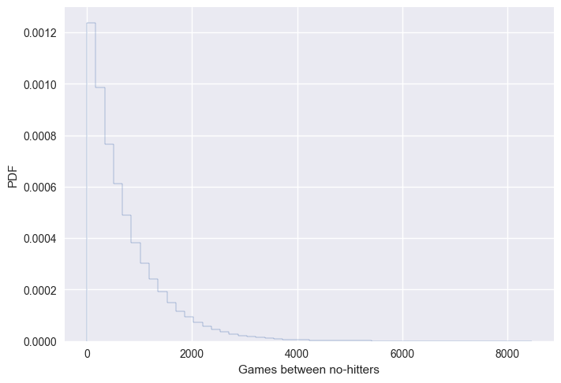

**Example #2: Theoretical vs Actual ECDF (Exponential for Time Between No-Hitters)**:

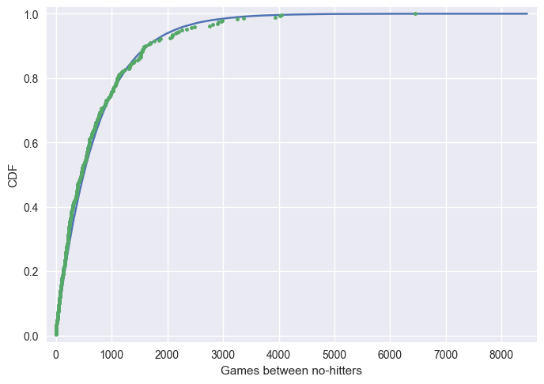

**Example #3: ECDF for Exponential Distribution with Half-Rate and Double-Rate**:

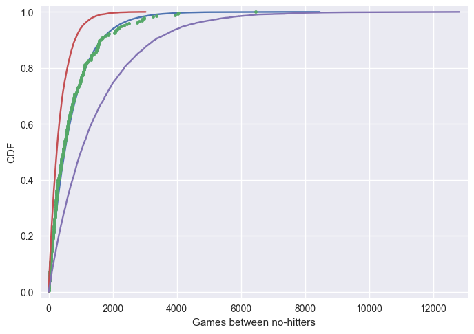

**Example #4: Scatter-Plot for Fertility vs Illiteracy (Gapminder)**:

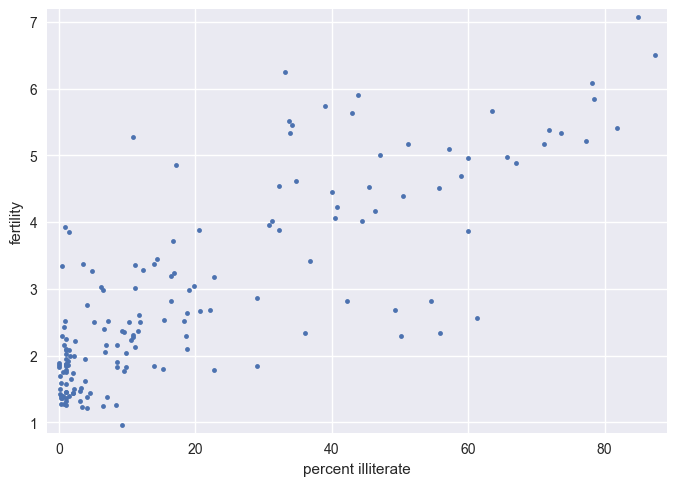

**Example #5: Best Linear Fit for Fertility vs Illiteracy (Gapminder)**:

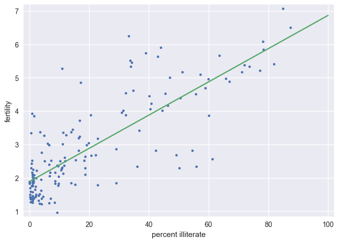

**Example #6: Residual Sum-Squares vs Best-Fit Parameters**:

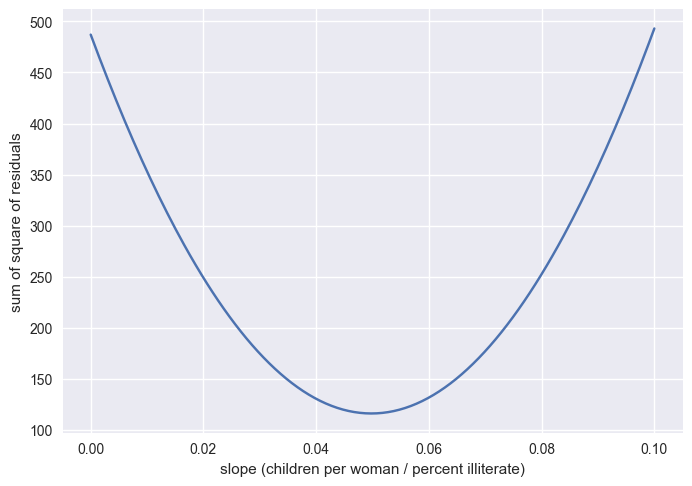

**Example #7: Regression Fit for Anscombe Data #1**:

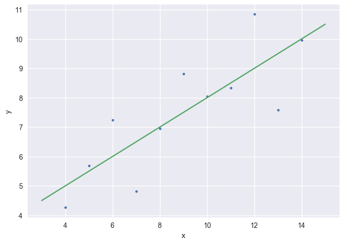

Chapter 2 - Bootstrap confidence intervals

Generating bootstrap replicates - how might the sample statistics change if we acquired a new sample:

- Hacker approach - resample the existing data (WITH replacement), using the same n, then recalculate the sample statistics
- Can then take multiple re-samples and aggregate the sample statistics for a statistical inference
- “Bootstrap replicate” is the value of the summary statistic calculated from the “bootstrap sample”
- Boostrap samples can easily be created in Python
  - np.random.choice(myData, size=len(myData)) # can specify any size, but len(myData) will be a bootstrap; sampling is WITH replacement

Bootstrap confidence intervals:

- Can generate a function bootstrap_replicate_1d(data, func) which takes a bootstrap sample of data and then applies func to it
- Can then use a for loop to run through the function, storing the results in a numpy array (or appended to an empty list, or etc.)
- Can generate the confidence interval using np.percentile(all_replicates, [2.5, 97.5]) # this is for the 95% confidence interval

Pairs bootstrap - bootstrap resample on pairs of data (e.g., keep the x and y connected to each other):

- Bootstrap approach is non-parametric, since it is not forced to fit any particular model
- Least-squares approach is parametrics, since it is forced to fit a pre-defined specification of the model
- Can use bootstrap techniques to get confidence intervals on the parametric (e.g., least-squares) models
  - Use a pairs bootstrap that keeps each of the x/y anchored to each other
  - Resample WITH replacement on all the x/y pairs, then run the model with this bootstrap resample
- The approach within Python is a slight modification of the 1D approach
  - inds = np.arange(len(myXYData))
  - bs_inds = np.random.choice(inds, len(inds))
  - Use bs_inds as the .iloc (or index) filters of the dataset

Example code includes:

```python
myPath = "./PythonInputFiles/"



import pandas as pd
import numpy as np
import seaborn as sns
import matplotlib.pyplot as plt



rawWeather = pd.read_csv(myPath + "sheffield_weather_station.csv", skiprows=8, delim_whitespace=True)
rainfall = rawWeather["rain"]


def ecdf(data):
    """Compute ECDF for a one-dimensional array of measurements."""

    # Number of data points: n
    n = len(data)

    # x-data for the ECDF: x
    x = np.sort(data)

    # y-data for the ECDF: y
    y = np.arange(1, n+1) / n

    return x, y



for a in range(50):
    # Generate bootstrap sample: bs_sample
    bs_sample = np.random.choice(rainfall, size=len(rainfall))

    # Compute and plot ECDF from bootstrap sample
    x, y = ecdf(bs_sample)
    _ = plt.plot(x, y, marker='.', linestyle='none',
                 color='gray', alpha=0.1)

# Compute and plot ECDF from original data
x, y = ecdf(rainfall)
_ = plt.plot(x, y, marker='.')

# Make margins and label axes
plt.margins(0.02)
_ = plt.xlabel('yearly rainfall (mm)')
_ = plt.ylabel('ECDF')

# Show the plot
# plt.show()
plt.savefig("_dummyPy174.png", bbox_inches="tight")
plt.clf()



def bootstrap_replicate_1d(data, func):
    return func(np.random.choice(data, size=len(data)))


def draw_bs_reps(data, func, size=1):
    """Draw bootstrap replicates."""

    # Initialize array of replicates: bs_replicates
    bs_replicates = np.empty(size)

    # Generate replicates
    for i in range(size):
        bs_replicates[i] = bootstrap_replicate_1d(data, func)

    return bs_replicates


# Take 10,000 bootstrap replicates of the mean: bs_replicates
bs_replicates = draw_bs_reps(rainfall, np.mean, 10000)

# Compute and print SEM
sem = np.std(rainfall) / np.sqrt(len(rainfall))
print(sem)

# Compute and print standard deviation of bootstrap replicates
bs_std = np.std(bs_replicates)
print(bs_std)

# Make a histogram of the results
_ = plt.hist(bs_replicates, bins=50, normed=True)
_ = plt.xlabel('mean annual rainfall (mm)')
_ = plt.ylabel('PDF')

# Show the plot
# plt.show()
plt.savefig("_dummyPy175.png", bbox_inches="tight")
plt.clf()


# Generate 10,000 bootstrap replicates of the variance: bs_replicates
bs_replicates = draw_bs_reps(rainfall, np.var, 10000)

# Put the variance in units of square centimeters
bs_replicates = bs_replicates / 100

# Make a histogram of the results
_ = plt.hist(bs_replicates, bins=50, normed=True)
_ = plt.xlabel('variance of annual rainfall (sq. cm)')
_ = plt.ylabel('PDF')

# Show the plot
#plt.show()
plt.savefig("_dummyPy176.png", bbox_inches="tight")
plt.clf()



rawNoHitter = pd.read_csv(myPath + "mlb_nohitters.csv", parse_dates=["date"])
nohitter_times = rawNoHitter["game_number"].diff()[1:]


# Draw bootstrap replicates of the mean no-hitter time (equal to tau): bs_replicates
bs_replicates = draw_bs_reps(nohitter_times, np.mean, 10000)

# Compute the 95% confidence interval: conf_int
conf_int = np.percentile(bs_replicates, [2.5, 97.5])

# Print the confidence interval
print('95% confidence interval =', conf_int, 'games')

# Plot the histogram of the replicates
_ = plt.hist(bs_replicates, bins=50, normed=True)
_ = plt.xlabel(r'$\tau$ (games)')
_ = plt.ylabel('PDF')

# Show the plot
# plt.show()
plt.savefig("_dummyPy177.png", bbox_inches="tight")
plt.clf()



def draw_bs_pairs_linreg(x, y, size=1):
    """Perform pairs bootstrap for linear regression."""

    # Set up array of indices to sample from: inds
    inds = np.arange(len(x))

    # Initialize replicates: bs_slope_reps, bs_intercept_reps
    bs_slope_reps = np.empty(size)
    bs_intercept_reps = np.empty(size)

    # Generate replicates
    for i in range(size):
        bs_inds = np.random.choice(inds, size=len(inds))
        bs_x, bs_y = x[bs_inds], y[bs_inds]
        bs_slope_reps[i], bs_intercept_reps[i] = np.polyfit(bs_x, bs_y, 1)

    return bs_slope_reps, bs_intercept_reps



rawGap = pd.read_csv(myPath + "literacy_birth_rate.csv", index_col=None)
fertility = rawGap["fertility"]
female_literacy = rawGap["female literacy"]
illiteracy = 100 - female_literacy

# Generate replicates of slope and intercept using pairs bootstrap
bs_slope_reps, bs_intercept_reps = draw_bs_pairs_linreg(illiteracy, fertility, 1000)

# Compute and print 95% CI for slope
print(np.percentile(bs_slope_reps, [2.5, 97.5]))

# Plot the histogram
_ = plt.hist(bs_slope_reps, bins=50, normed=True)
_ = plt.xlabel('slope')
_ = plt.ylabel('PDF')

# plt.show()
plt.savefig("_dummyPy178.png", bbox_inches="tight")
plt.clf()


# Generate array of x-values for bootstrap lines: x
x = np.array([0, 100])

# Plot the bootstrap lines
for i in range(100):
    _ = plt.plot(x, bs_slope_reps[i]*x + bs_intercept_reps[i],
                 linewidth=0.5, alpha=0.2, color='red')

# Plot the data
_ = plt.plot(illiteracy, fertility, marker=".", linestyle="none")

# Label axes, set the margins, and show the plot
_ = plt.xlabel('illiteracy')
_ = plt.ylabel('fertility')
plt.margins(0.02)

# plt.show()
plt.savefig("_dummyPy179.png", bbox_inches="tight")
plt.clf()
```

```
## 0.948859357468
## 0.953606472748
## 95% confidence interval = [ 630.12576792  817.16518771] games
## [ 0.04404395  0.05540483]
```

**Example #1: Bootstrap ECDF for Sheffield Annual Rainfall**:

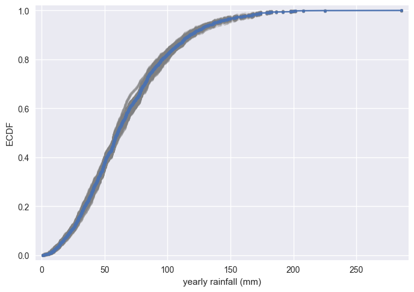

**Example #2: Bootstrap Mean for Sheffield Annual Rainfall**:

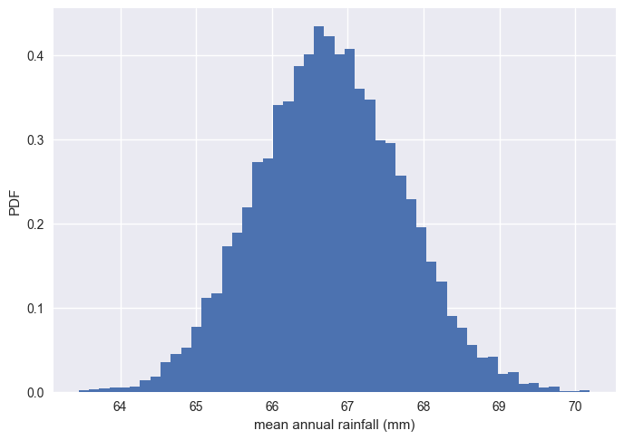

**Example #3: Bootstrap Variance for Sheffield Annual Rainfall**:

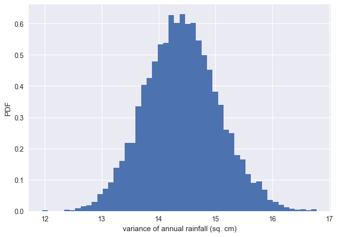

**Example #4: Bootstrap for No-Hitter Times**:

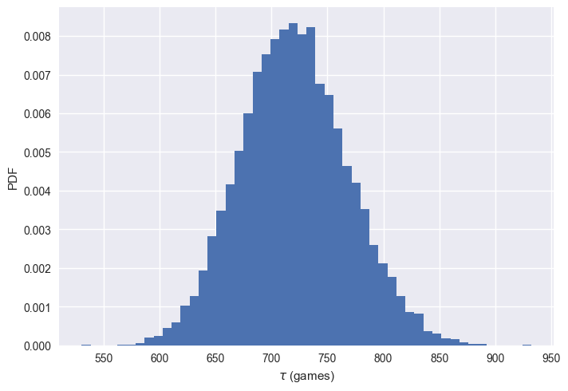

**Example #5: Bootstrap Pairs for Fertility vs Illiteracy (Gapminder)**:

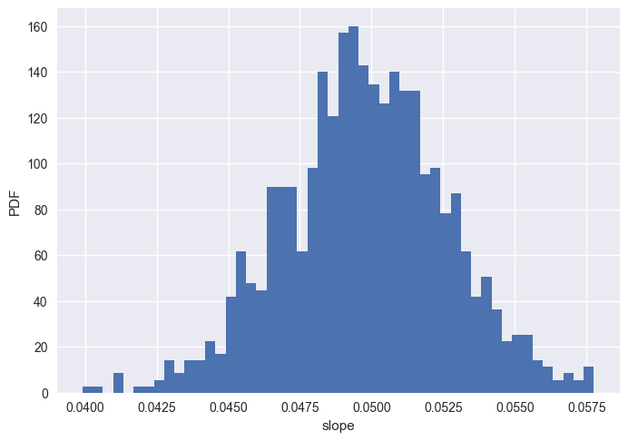

**Example #6: Bootstrap Pairs for Fertility vs Illiteracy (Gapminder)**:

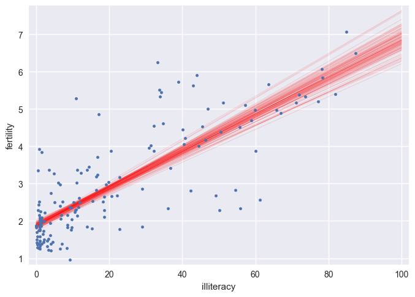

Chapter 3 - Hypothesis Testing